# 📊 Guia Completo de Painel Dinâmico & System-GMM em Python

**Autor:** Dr. Silvio da Rosa Paula — Doutor em Economia Aplicada | Cientista de Dados  
**Portfólio:** [GitHub](https://github.com/silviopaula) • [LinkedIn](https://www.linkedin.com/in/silvio-paula/) • [Artigos Publicados](https://github.com/silviopaula/Portifolio-Artigos-Publicados-Economia)

## 🎯 Objetivo deste Guia

Este notebook apresenta um roteiro **teórico, simulado e empírico** para estimar, diagnosticar e interpretar modelos de **Painel Dinâmico** via **Difference-GMM (Arellano & Bond, 1991)** e **Two-Step System-GMM (Blundell & Bond, 1998)** com correção de amostra finita de **Windmeijer (2005)** integralmente em **Python** (`pydynpd` + `linearmodels` + `scipy`).

O guia está estruturado em **5 blocos didáticos**:

1. **Fundamentação Econométrica**: por que Pooled OLS e Efeitos Fixos falham em painéis dinâmicos (**Viés de Nickell**), a regra do **Intervalo de Bond (2002)**, a evolução de Anderson–Hsiao até System-GMM e os testes diagnósticos (**AR(1), AR(2), Hansen J** e proliferação de instrumentos).
2. **Laboratório Monte Carlo (25 Replicações)**: prova empírica com parâmetros verdadeiros conhecidos demonstrando o viés positivo do OLS, o viés negativo de Nickell no FE, a distorção causada por regressores endógenos e como o **System-GMM** recupera o efeito causal verdadeiro.
3. **Aplicação Empírica Real (`data/BASE_CH.dta`, 27 UFs do Brasil, 1996–2015)**: replicação e análise baseada no artigo publicado na *Revista Brasileira de Economia* — [*Economic Growth Channels From Human Capital: A Dynamic Panel Analysis for Brazil*](https://www.scielo.br/j/rbe/a/KkYHXdsxP7nXzLRBCbY64Vq/?lang=en), incluindo o colapso do teste de Hansen por proliferação de instrumentos, separação entre **Educação Básica** e **Educação Superior**, e estimação dos **Efeitos de Longo Prazo via Método Delta** (equivalente em Python ao `nlcom` do Stata).
4. **Validação Cruzada (`pydynpd` vs. `xtabond2` do Stata) e Curva de Robustez (*Specification Curve*)**: avaliação transparente de sensibilidade entre especificações econometricamente válidas.
5. **Guia de Equivalência de Sintaxe (`xtabond2` ↔ `pydynpd`)** e referências bibliográficas essenciais.

## 1. Fundamentação Econométrica: Painel Dinâmico e System-GMM

### 1.1 O que é um Painel Dinâmico e por que usá-lo?

Diferentemente de um painel estático, um **painel dinâmico** inclui a própria variável dependente defasada ($Y_{i,t-1}$) como regressor explicativo:

$$Y_{it} = \gamma Y_{i,t-1} + X'_{it}\beta + \mu_i + \varepsilon_{it}, \qquad i = 1,\dots,N, \quad t = 2,\dots,T$$

onde:

- $\gamma$ mede o grau de **persistência / inércia** (ou convergência condicional em modelos de crescimento);
- $X_{it}$ é o vetor de covariáveis (que podem ser **estritamente exógenas**, **predeterminadas** ou **endógenas**);
- $\mu_i$ representa a **heterogeneidade não observada invariante no tempo** (efeito fixo individual de cada estado, firma ou país);
- $\varepsilon_{it}$ é o choque idiossincrático (assumido serialmente não correlacionado).

**Quando usar?** Em macroeconomia, finanças corporativas e economia aplicada (crescimento econômico, produtividade, investimento, inadimplência, receita recorrente), as decisões presentes dependem fortemente das realizações passadas por fricções tecnológicas, institucionais e comportamentais — além de ser quase impossível encontrar instrumentos *externos* perfeitamente exógenos para variáveis agregadas.

### 1.2 O Duplo Dilema: Viés do Pooled OLS, Viés de Nickell (FE) e o Intervalo de Bond (2002)

Por que não podemos simplesmente estimar a equação acima por **Pooled OLS** ou **Efeitos Fixos (Within / FE)**?

1. **Pooled OLS enviesa $\hat{\gamma}$ para CIMA**: como $Y_{i,t-1}$ depende de $\mu_i$, e $\mu_i$ faz parte do erro composto $(\mu_i + \varepsilon_{it})$, temos $\text{Cov}(Y_{i,t-1}, \mu_i) > 0$, atribuindo indevidamente ao parâmetro $\gamma$ parte da heterogeneidade fixa entre unidades.
2. **Efeitos Fixos (Within / FE) enviesa $\hat{\gamma}$ para BAIXO — Viés de Nickell (1981)**: ao subtrair as médias individuais ($\tilde{Y}_{it} = Y_{it} - \bar{Y}_i$), o regressor transformado $(Y_{i,t-1} - \bar{Y}_{i,-1})$ correlaciona-se **negativamente** com o erro transformado $(\varepsilon_{it} - \bar{\varepsilon}_i)$, pois $\bar{\varepsilon}_i$ contém $\varepsilon_{i,t-1}$. Em painéis com $T$ pequeno, o viés é severo — da ordem de $-\frac{1+\gamma}{T-1}$ — e **não desaparece mesmo quando $N \to \infty$**.
3. **Regra Prática de Bond (2002)**: em painéis bem comportados (sem endogeneidade severa nas demais covariáveis), os estimadores Pooled OLS e Fixed Effects formam, respectivamente, o **limite superior** e o **limite inferior** para o parâmetro verdadeiro de persistência:

$$\hat{\gamma}_{\text{FE}} \;\le\; \hat{\gamma}_{\text{GMM consistente}} \;\le\; \hat{\gamma}_{\text{OLS}}$$

### 1.3 Evolução dos Estimadores de Painel Dinâmico

| Estimador | Ideia Central | Vantagens | Limitações |
| --- | --- | --- | --- |
| **Anderson & Hsiao (1981)** | Aplica primeira diferença ($\Delta Y_{it} = \gamma \Delta Y_{i,t-1} + \Delta X'_{it}\beta + \Delta \varepsilon_{it}$) eliminando $\mu_i$, e usa $Y_{i,t-2}$ (ou $\Delta Y_{i,t-2}$) como instrumento par… | Consistente para $N \to \infty$ com $T$ fixo. | Ineficiente: usa apenas uma defasagem como instrumento (exatamente identificado). |
| **Arellano & Bond (1991)** (*Diff-GMM*) | Explora **todas** as condições de momento válidas em níveis defasados ($Y_{i,t-2}, Y_{i,t-3}, \dots$) para instrumentar a equação em primeira diferença via GMM em 1 ou 2 estágios. | Muito mais eficiente que Anderson–Hsiao; permite endogeneidade em $X_{it}$. | **Instrumentos fracos** quando a série é altamente persistente ($\gamma \to 1$), enviesando $\hat{\gamma}$ para baixo (próximo ao FE). |
| **Arellano & Bover (1995)** (*FOD*) | Substitui a primeira diferença pelos **Desvios Ortogonais para Frente (FOD)**: subtrai de cada observação a média de todas as observações *futuras* disponíveis. | Preserva tamanho amostral em **painéis desbalanceados** com lacunas (*missings*). | Mantém necessidade de momentos adicionais para séries muito persistentes. |
| **Blundell & Bond (1998)** (*System-GMM*) | Estima simultaneamente um **sistema** com a equação em diferenças (instrumentada por níveis defasados) + a equação em **nível** (instrumentada por diferenças defasadas $\Delta Y_{i,t-1}$). | Reduz drasticamente o viés de instrumentos fracos e aumenta eficiência; com **Windmeijer (2005)** corrige erros-padrão em amostra finita (*two-step*). | Exige estacionariedade em média ($\mathbb{E}[\Delta Y_{i,t-1}\mu_i] = 0$) e sofre de **proliferação quadrática de instrumentos** ($O(T^2)$) se não controlada. |

### 1.4 Proliferação de Instrumentos e Checklist de Diagnósticos (Roodman, 2009)

Sem controle, o número de instrumentos internos cresce **quadraticamente em $T$**. Excesso de instrumentos gera *overfitting* das variáveis endógenas (aproximando o GMM do OLS enviesado) e **enfraquece drasticamente o teste de Hansen**, produzindo *p-valores* artificialmente próximos de `1,000`.

**Três técnicas clássicas de controle:**

- **`Laglimits`**: limita a profundidade das defasagens usadas como instrumentos (ex.: `2:4` ou `2:7`).
- **`Collapse`**: empilha as colunas de instrumentos por defasagem em vez de criar uma coluna separada para cada período $t$, reduzindo o crescimento de $O(T^2)$ para $O(T)$.
- **`PCA`**: aplica Análise de Componentes Principais sobre a matriz de instrumentos (disponível no `xtabond2` do Stata).

**Guia de leitura dos testes diagnósticos (Two-Step System-GMM):**

| Diagnóstico | Hipótese Nula ($H_0$) | Critério de Aprovação | Alerta Vermelho |
| --- | --- | --- | --- |
| **Arellano–Bond AR(1)** | Ausência de autocorrelação de 1ª ordem em $\Delta \varepsilon_{it}$ | **$p < 0{,}05$** *(esperado rejeitar $H_0$, pois $\Delta\varepsilon_{it}$ e $\Delta\varepsilon_{i,t-1}$ compartilham $\varepsilon_{i,t-1}$)* | Se $p > 0{,}10$, indica erro original com dinâmica incomum |
| **Arellano–Bond AR(2)** | Ausência de autocorrelação de 2ª ordem em $\Delta \varepsilon_{it}$ | **$p > 0{,}10$** *(não rejeitar $H_0$ valida defasagens a partir de $t-2$)* | Se $p < 0{,}05$, há autocorrelação em $\varepsilon_{it}$ → recuar lags para `3:` |
| **Hansen J** *(Two-Step)* | Instrumentos são conjuntamente válidos (exógenos) | **$0{,}10 \le p \le 0{,}80$** *(Roodman, 2009)* | $p < 0{,}05$: instrumentos inválidos; **$p > 0{,}90$ ou `1,000`**: excesso de instrumentos! |
| **Sargan** | Instrumentos válidos *(sob homocedasticidade)* | Reportar apenas em **One-Step** | Não robusto em Two-Step com heterocedasticidade |
| **Nº Instrumentos vs. Grupos** | Regra de parcimônia | **$\text{Instrumentos} \le N_{\text{grupos}}$** | Se $\text{Instrumentos} \gg N$, o teste de Hansen perde poder |

## 2. Configuração do Ambiente Python

> **Nota técnica importante (NumPy ≥ 2.0):** o pacote `pydynpd` ainda referencia o alias legado `np.NaN`, removido a partir do NumPy 2.0. Aplicamos um *shim* leve de compatibilidade (`np.NaN = np.nan`) antes da importação para que todo o notebook rode perfeitamente tanto em ambientes Python 3.10–3.11 (NumPy 1.x) quanto Python 3.12–3.14 (NumPy 2.x).

```python
import contextlib
import io
import warnings
from pathlib import Path

import numpy as np

# Compatibilidade do pydynpd com NumPy >= 2.0
if not hasattr(np, "NaN"):
    np.NaN = np.nan

import matplotlib.pyplot as plt
import pandas as pd
import pyreadstat
import seaborn as sns
import statsmodels.api as sm
from linearmodels.panel import PanelOLS, PooledOLS
from pydynpd import regression
from scipy import stats

warnings.filterwarnings("ignore")

# Estilo visual consistente para gráficos de publicação
plt.rcParams.update(
    {
        "figure.dpi": 120,
        "axes.spines.top": False,
        "axes.spines.right": False,
        "axes.grid": True,
        "grid.alpha": 0.25,
        "font.size": 10,
    }
)
sns.set_palette("deep")

DATA_PATH = Path("data/BASE_CH.dta")
IMG_DIR = Path("img")
IMG_DIR.mkdir(exist_ok=True)


def run_abond_quiet(formula: str, df: pd.DataFrame, ids: list[str]):
    '''Executa pydynpd.regression.abond silenciando o stdout verboso e retornando o modelo.'''
    buf = io.StringIO()
    with contextlib.redirect_stdout(buf):
        res = regression.abond(formula, df, ids)
    return res.models[0], buf.getvalue()


def extract_model_summary(model, var_interesse: str | None = None) -> dict:
    '''Extrai coeficientes, erros-padrão Windmeijer e diagnósticos AR(1)/AR(2)/Hansen de um modelo pydynpd.'''
    tbl = model.regression_table.set_index("variable")
    ar1_p = float(model.AR_list[0].P_value) if len(model.AR_list) > 0 else np.nan
    ar2_p = float(model.AR_list[1].P_value) if len(model.AR_list) > 1 else np.nan
    hansen_p = float(model.hansen.p_value) if model.hansen is not None else np.nan
    n_inst = int(model.z_information.num_instr)
    out = {
        "N_obs": int(model.num_obs),
        "N_grupos": int(model.N),
        "Instrumentos": n_inst,
        "AR1_p": ar1_p,
        "AR2_p": ar2_p,
        "Hansen_p": hansen_p,
    }
    if var_interesse and var_interesse in tbl.index:
        out["coef"] = float(tbl.loc[var_interesse, "coefficient"])
        out["se"] = float(tbl.loc[var_interesse, "std_err"])
        out["p_val"] = float(tbl.loc[var_interesse, "p_value"])
    return out


print(f"Ambiente pronto! NumPy {np.__version__} | Pandas {pd.__version__} | Base encontrada: {DATA_PATH.exists()}")
```

```
Ambiente pronto! NumPy 2.3.4 | Pandas 2.3.3 | Base encontrada: True
```

## 3. Laboratório Monte Carlo: Provando o Viés de Nickell e a Consistência do System-GMM

Antes de irmos aos dados reais dos estados brasileiros, vamos construir um **experimento controlado (Monte Carlo)** onde **nós conhecemos os parâmetros verdadeiros** do processo gerador de dados (DGP):

$$Y_{it} = \underbrace{0{,}60}_{\gamma}\,Y_{i,t-1} + \underbrace{0{,}40}_{\beta_1}\,x_{1,it} + \underbrace{0{,}30}_{\beta_2}\,x_{2,it} + \underbrace{0{,}25}_{\beta_3}\,x_{3,it} + \underbrace{0{,}20}_{\delta}\,z_{it} + \mu_i + \varepsilon_{it}$$

**Desenho econométrico realista do DGP:**

- **$N = 400$ unidades e $T = 8$ períodos observados** (após *burn-in* de 30 períodos para garantir a condição de estacionariedade em média de Blundell & Bond, 1998 — ou seja, $\mathbb{E}[\Delta Y_{i,t-1}\mu_i] = 0$).
- **$x_1$ e $x_2$ são endógenos**: correlacionados tanto com o efeito fixo $\mu_i$ quanto com o choque contemporâneo $\varepsilon_{it}$ (causalidade reversa / variável omitida variantes no tempo).
- **$x_3$ é correlacionado com o efeito fixo $\mu_i$**, mas não com $\varepsilon_{it}$.
- **$z$ é estritamente exógeno**.

Vamos estimar **25 replicações independentes** comparando 4 estimadores clássicos:

1. **Pooled OLS** (ignora $\mu_i$ e endogeneidade)
2. **Efeitos Fixos / Within (`PanelOLS`)** (elimina $\mu_i$, mas sofre do **Viés de Nickell** em $\gamma$ e não corrige endogeneidade contemporânea de $x_1, x_2$)
3. **Two-Step Difference-GMM** (`pydynpd` com `nolevel collapse`)
4. **Two-Step System-GMM** (`pydynpd` com `collapse` e correção de Windmeijer)

```python
TRUE_PARAMS = {"L1.y": 0.60, "x1": 0.40, "x2": 0.30, "x3": 0.25, "z": 0.20}


def simular_painel_estacionario(N: int = 400, T: int = 8, burn: int = 30, seed: int = 42) -> pd.DataFrame:
    '''Gera painel dinâmico estacionário (Blundell-Bond 1998) com endogeneidade controlada.'''
    rng = np.random.default_rng(seed)
    gamma = TRUE_PARAMS["L1.y"]
    b1, b2, b3, dz = TRUE_PARAMS["x1"], TRUE_PARAMS["x2"], TRUE_PARAMS["x3"], TRUE_PARAMS["z"]

    u = rng.normal(0.0, 1.0, size=N)
    y_prev = np.zeros(N)
    x1_prev = np.zeros(N)
    x2_prev = np.zeros(N)
    x3_prev = np.zeros(N)

    records = []
    for step in range(1, burn + T + 1):
        eps = rng.normal(0.0, 1.0, size=N)
        z = rng.normal(0.0, 1.0, size=N)

        x1 = 0.55 * x1_prev + 0.40 * u + 0.45 * eps + rng.normal(0.0, 1.0, size=N)
        x2 = 0.50 * x2_prev + 0.30 * u + 0.35 * eps + rng.normal(0.0, 1.0, size=N)
        x3 = 0.45 * x3_prev + 0.25 * u + rng.normal(0.0, 1.0, size=N)
        y = gamma * y_prev + b1 * x1 + b2 * x2 + b3 * x3 + dz * z + u + eps

        if step > burn:
            t = step - burn
            records.append(
                pd.DataFrame(
                    {
                        "id": np.arange(1, N + 1),
                        "t": t,
                        "y": y,
                        "L1_y": y_prev,
                        "x1": x1,
                        "x2": x2,
                        "x3": x3,
                        "z": z,
                    }
                )
            )
        y_prev, x1_prev, x2_prev, x3_prev = y, x1, x2, x3

    return pd.concat(records, ignore_index=True).sort_values(["id", "t"]).reset_index(drop=True)


# Experimento Monte Carlo com 25 replicações independentes
N_REPS = 25
mc_rows = []
diag_sgmm = []

formula_dgmm = "y L1.y x1 x2 x3 z | gmm(y x1 x2 x3, 2:4) iv(z) | nolevel collapse"
formula_sgmm = "y L1.y x1 x2 x3 z | gmm(y x1 x2 x3, 2:4) iv(z) | collapse"

for rep in range(N_REPS):
    df_sim = simular_painel_estacionario(N=400, T=8, burn=30, seed=100 + rep)
    idx_sim = df_sim[df_sim["t"] >= 2].set_index(["id", "t"])
    cols_x = ["L1_y", "x1", "x2", "x3", "z"]

    # 1. Pooled OLS
    res_ols = PooledOLS(idx_sim["y"], sm.add_constant(idx_sim[cols_x])).fit(
        cov_type="clustered", cluster_entity=True
    )
    # 2. Fixed Effects (Within)
    res_fe = PanelOLS(idx_sim["y"], idx_sim[cols_x], entity_effects=True).fit(
        cov_type="clustered", cluster_entity=True
    )
    # 3. Two-Step Diff-GMM
    m_dgmm, _ = run_abond_quiet(formula_dgmm, df_sim, ["id", "t"])
    tbl_d = m_dgmm.regression_table.set_index("variable")
    # 4. Two-Step System-GMM
    m_sgmm, _ = run_abond_quiet(formula_sgmm, df_sim, ["id", "t"])
    tbl_s = m_sgmm.regression_table.set_index("variable")

    diag_sgmm.append(extract_model_summary(m_sgmm))

    for est_name, mapping in [
        ("Pooled OLS", {"L1.y": res_ols.params["L1_y"], "x1": res_ols.params["x1"], "x2": res_ols.params["x2"], "x3": res_ols.params["x3"], "z": res_ols.params["z"]}),
        ("Fixed Effects (FE)", {"L1.y": res_fe.params["L1_y"], "x1": res_fe.params["x1"], "x2": res_fe.params["x2"], "x3": res_fe.params["x3"], "z": res_fe.params["z"]}),
        ("Diff-GMM (2-Step)", {k: float(tbl_d.loc[k, "coefficient"]) for k in TRUE_PARAMS}),
        ("System-GMM (2-Step)", {k: float(tbl_s.loc[k, "coefficient"]) for k in TRUE_PARAMS}),
    ]:
        row = {"rep": rep, "Estimador": est_name}
        row.update(mapping)
        mc_rows.append(row)

df_mc_res = pd.DataFrame(mc_rows)
df_diag_mc = pd.DataFrame(diag_sgmm)

# Resumo estatístico: Média, Viés Médio e RMSE nas 25 replicações
summary_rows = []
for est in ["Pooled OLS", "Fixed Effects (FE)", "Diff-GMM (2-Step)", "System-GMM (2-Step)"]:
    sub = df_mc_res[df_mc_res["Estimador"] == est]
    r = {"Estimador": est}
    for k, true_v in TRUE_PARAMS.items():
        mean_v = sub[k].mean()
        r[f"{k} (média)"] = round(mean_v, 3)
        r[f"{k} (viés)"] = round(mean_v - true_v, 3)
    summary_rows.append(r)

df_mc_summary = pd.DataFrame(summary_rows)
print("=== RESUMO MONTE CARLO (25 replicações, N=400, T=8) ===")
print(f"Valores Verdadeiros: {TRUE_PARAMS}\n")
display(df_mc_summary[["Estimador", "L1.y (média)", "L1.y (viés)", "x1 (média)", "x1 (viés)", "x2 (média)", "x3 (média)", "z (média)"]])

print(
    f"\nDiagnósticos Médios do System-GMM (25 replicações): "
    f"Instrumentos = {df_diag_mc['Instrumentos'].mean():.0f} | "
    f"Mediana AR(1) p = {df_diag_mc['AR1_p'].median():.4f} | "
    f"Mediana AR(2) p = {df_diag_mc['AR2_p'].median():.3f} | "
    f"Mediana Hansen J p = {df_diag_mc['Hansen_p'].median():.3f}"
)
```

```
=== RESUMO MONTE CARLO (25 replicações, N=400, T=8) ===
Valores Verdadeiros: {'L1.y': 0.6, 'x1': 0.4, 'x2': 0.3, 'x3': 0.25, 'z': 0.2}
```

|  | Estimador | L1.y (média) | L1.y (viés) | x1 (média) | x1 (viés) | x2 (média) | x3 (média) | z (média) |
| --- | --- | --- | --- | --- | --- | --- | --- | --- |
| 0 | Pooled OLS | 0.688 | 0.088 | 0.686 | 0.286 | 0.541 | 0.314 | 0.209 |
| 1 | Fixed Effects (FE) | 0.398 | -0.202 | 0.716 | 0.316 | 0.551 | 0.257 | 0.192 |
| 2 | Diff-GMM (2-Step) | 0.590 | -0.010 | 0.421 | 0.021 | 0.328 | 0.240 | 0.206 |
| 3 | System-GMM (2-Step) | 0.594 | -0.006 | 0.419 | 0.019 | 0.330 | 0.241 | 0.208 |

```
Diagnósticos Médios do System-GMM (25 replicações): Instrumentos = 18 | Mediana AR(1) p = 0.0000 | Mediana AR(2) p = 0.497 | Mediana Hansen J p = 0.624
```

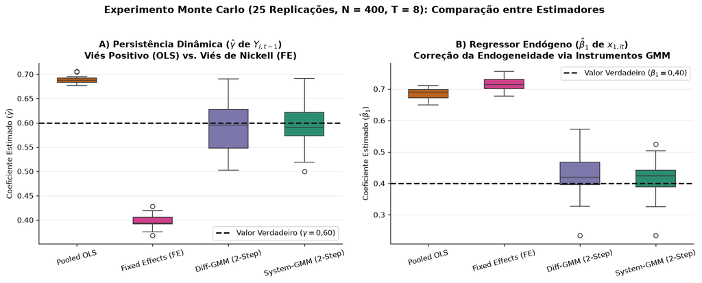

```python
# Gráfico 1 — Visualização do Viés de Nickell, Viés de Endogeneidade e Consistência do System-GMM
fig, axes = plt.subplots(1, 2, figsize=(13.5, 5.2))

order_est = ["Pooled OLS", "Fixed Effects (FE)", "Diff-GMM (2-Step)", "System-GMM (2-Step)"]
palette = {
    "Pooled OLS": "#d95f02",
    "Fixed Effects (FE)": "#e7298a",
    "Diff-GMM (2-Step)": "#7570b3",
    "System-GMM (2-Step)": "#1b9e77",
}

# Painel A: Persistência (gamma = 0.60)
sns.boxplot(
    data=df_mc_res,
    x="Estimador",
    y="L1.y",
    order=order_est,
    palette=palette,
    width=0.52,
    ax=axes[0],
)
axes[0].axhline(TRUE_PARAMS["L1.y"], color="#111111", linestyle="--", linewidth=2, label="Valor Verdadeiro ($\\gamma = 0{,}60$)")
axes[0].set_title("A) Persistência Dinâmica ($\\hat{\\gamma}$ de $Y_{i,t-1}$)\nViés Positivo (OLS) vs. Viés de Nickell (FE)", fontweight="bold")
axes[0].set_xlabel("")
axes[0].set_ylabel("Coeficiente Estimado ($\\hat{\\gamma}$)")
axes[0].tick_params(axis="x", rotation=15)
axes[0].legend(loc="lower right", frameon=True)

# Painel B: Regressor Endógeno x1 (beta1 = 0.40)
sns.boxplot(
    data=df_mc_res,
    x="Estimador",
    y="x1",
    order=order_est,
    palette=palette,
    width=0.52,
    ax=axes[1],
)
axes[1].axhline(TRUE_PARAMS["x1"], color="#111111", linestyle="--", linewidth=2, label="Valor Verdadeiro ($\\beta_1 = 0{,}40$)")
axes[1].set_title("B) Regressor Endógeno ($\\hat{\\beta}_1$ de $x_{1,it}$)\nCorreção da Endogeneidade via Instrumentos GMM", fontweight="bold")
axes[1].set_xlabel("")
axes[1].set_ylabel("Coeficiente Estimado ($\\hat{\\beta}_1$)")
axes[1].tick_params(axis="x", rotation=15)
axes[1].legend(loc="upper right", frameon=True)

fig.suptitle("Experimento Monte Carlo (25 Replicações, N = 400, T = 8): Comparação entre Estimadores", fontsize=13, fontweight="bold", y=1.02)
plt.tight_layout()
plt.savefig(IMG_DIR / "monte_carlo_vies_nickell_gmm.png", dpi=150, bbox_inches="tight")
plt.show()
```

### 💡 Leitura Didática do Experimento Monte Carlo

Os dois gráficos acima resumem, em uma imagem, **toda a razão de existir da econometria de painel dinâmico**:

1. **No Painel A ($\hat{\gamma}$ de $Y_{i,t-1}$, verdadeiro $= 0{,}600$)**:
   - **Pooled OLS** superestima sistematicamente a persistência ($\approx 0{,}688$, viés de `+0,088` causado por $\text{Cov}(Y_{i,t-1}, \mu_i) > 0$).
   - **Fixed Effects (FE)** despenca para $\approx 0{,}398$ — uma subestimação drástica de **`-0,202` (-34%)**, ilustrando exatamente o **Viés de Nickell (1981)** em $T = 8$.
   - **Diff-GMM** ($\approx 0{,}590$) e **System-GMM** ($\approx 0{,}594$, viés de apenas `-0,006`) eliminam o viés de Nickell e centram a distribuição sobre $\gamma = 0{,}600$ — com o **System-GMM** exibindo **menor dispersão (maior eficiência)** graças às condições de momento extras na equação em nível.
2. **No Painel B ($\hat{\beta}_1$ de $x_{1,it}$, verdadeiro $= 0{,}400$)**:
   - Tanto **OLS** ($\approx 0{,}686$) quanto **FE** ($\approx 0{,}716$) sofrem com a endogeneidade contemporânea ($\text{Cov}(x_{1,it}, \varepsilon_{it}) > 0$) e superestimam o efeito causal em **+72% a +79%**!
   - Apenas **Diff-GMM** ($\approx 0{,}421$) e **System-GMM** ($\approx 0{,}419$) utilizam as defasagens internas válidas (`gmm(x1, 2:4)`) para isolar a variação exógena e recuperar $\hat{\beta}_1 \approx 0{,}400$, passando simultaneamente em **AR(1)** ($p < 0{,}001$), **AR(2)** (mediana $p = 0{,}497$) e **Hansen J** (mediana $p = 0{,}624$).

## 4. Aplicação Empírica Real: Capital Humano e Crescimento Econômico nos Estados Brasileiros (1996–2015)

Agora aplicamos o estimador **Two-Step System-GMM** aos dados reais do artigo publicado na *Revista Brasileira de Economia* (SciELO):

> Paula, S. R., & colaboradores — [*Economic Growth Channels From Human Capital: A Dynamic Panel Analysis for Brazil*](https://www.scielo.br/j/rbe/a/KkYHXdsxP7nXzLRBCbY64Vq/?lang=en).

### 4.1 Estrutura Teórica e Dicionário de Variáveis (`data/BASE_CH.dta`)

O estudo investiga por quais canais o **Capital Humano** impulsiona a produtividade por trabalhador nas **27 Unidades da Federação (UFs)** entre **1996 e 2015** ($N = 27, T = 20$):

- **Canal de Solow (1956) / Mankiw–Romer–Weil**: acumulação de capital físico e taxa de crescimento do capital humano (`Tx_HC`, `Tx_HC_bh`, `Tx_HC_ah`).
- **Canal de Nelson & Phelps (1966) / Benhabib–Spiegel**: o **nível** de estoque de capital humano (`ln_HC`, distinguindo **Educação Básica** `ln_HC_bh` e **Educação Superior** `ln_HC_ah`) acelera a adoção de tecnologia e a inovação na fronteira produtiva.

| Variável | Descrição Econômica | Papel Econométrico |
| --- | --- | --- |
| `id`, `Ano` | Identificador da UF (`1..27`) e Ano (`1996..2015`) | Chaves do painel balanceado |
| `lnY_L` / `DlnY_L` | Log da produtividade (PIB por trabalhador) e sua 1ª diferença | Variável dependente ($Y_{it}$) e defasagem (`L1.lnY_L`) |
| `Tx_K_L` | Proxy de capital físico por trabalhador (em log) | Regressor endógeno (`gmm`) |
| `ln_HC`, `ln_HC_bh`, `ln_HC_ah` | Estoque de capital humano (Total, Educação Básica e Superior, em log) | Regressores de interesse (canal de nível / inovação) |
| `Tx_HC`, `Tx_HC_bh`, `Tx_HC_ah` | Taxa de crescimento do capital humano (Total, Básica e Superior) | Regressores de interesse (canal de acumulação) |
| `ln_Gec` | Log dos gastos públicos econômicos/infraestrutura | Controle macroeconômico (`iv`) |
| `popgr` | Taxa de crescimento populacional | Controle demográfico (`iv`) |
| `D_Crisis`, `Trend` | Dummy de períodos de crise e tendência temporal | Controles de choque comum (`iv`) |
| `n_prof_bh`, `n_prof_ah` | Número de professores (ensino básico e superior) | Instrumentos externos adicionais (`iv`) |

```
Dimensões da base BASE_CH.dta: 540 linhas x 19 colunas | UFs (N) = 27 | Anos (T) = 20 (1996–2015)
```

|  | count | mean | std | min | 50% | max |
| --- | --- | --- | --- | --- | --- | --- |
| lnY_L | 540.0 | 3.2811 | 0.5005 | 2.1375 | 3.2821 | 4.8816 |
| DlnY_L | 513.0 | 0.0130 | 0.0778 | -0.4170 | 0.0109 | 0.2990 |
| Tx_K_L | 540.0 | -5.3857 | 0.5348 | -6.6840 | -5.3700 | -3.8514 |
| ln_HC | 540.0 | -13.1603 | 1.2217 | -15.8462 | -13.2600 | -9.5368 |
| ln_HC_bh | 540.0 | -13.7400 | 1.2114 | -16.3026 | -13.7968 | -9.8967 |
| ln_HC_ah | 540.0 | -12.5386 | 1.2338 | -15.2963 | -12.6626 | -9.0346 |
| Tx_HC | 513.0 | -0.0569 | 0.1283 | -0.4338 | -0.0728 | 0.6985 |
| ln_Gec | 540.0 | 20.9689 | 0.9651 | 18.8973 | 20.7745 | 23.9201 |
| popgr | 513.0 | 0.0160 | 0.0161 | -0.0695 | 0.0141 | 0.0869 |
| D_Crisis | 540.0 | 0.3500 | 0.4774 | 0.0000 | 0.0000 | 1.0000 |

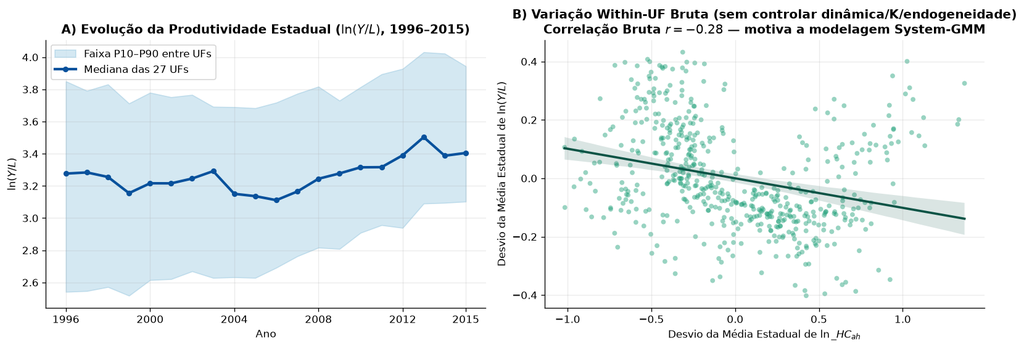

```python
df_br, meta_br = pyreadstat.read_dta(str(DATA_PATH))
df_br = df_br.sort_values(["id", "Ano"]).reset_index(drop=True)

print(
    f"Dimensões da base BASE_CH.dta: {df_br.shape[0]} linhas x {df_br.shape[1]} colunas | "
    f"UFs (N) = {df_br['id'].nunique()} | Anos (T) = {df_br['Ano'].nunique()} "
    f"({int(df_br['Ano'].min())}–{int(df_br['Ano'].max())})"
)

cols_eda = ["lnY_L", "DlnY_L", "Tx_K_L", "ln_HC", "ln_HC_bh", "ln_HC_ah", "Tx_HC", "ln_Gec", "popgr", "D_Crisis"]
display(df_br[cols_eda].describe().T[["count", "mean", "std", "min", "50%", "max"]].round(4))

# Gráfico 2 — EDA do painel brasileiro: trajetória da produtividade e associação com capital humano superior
fig, axes = plt.subplots(1, 2, figsize=(13.5, 4.8))

# Painel A: Evolução da produtividade estadual (mediana e faixa interdecil P10-P90)
grp_yr = df_br.groupby("Ano")["lnY_L"].agg(
    mediana="median",
    p10=lambda s: np.percentile(s, 10),
    p90=lambda s: np.percentile(s, 90),
).reset_index()

axes[0].fill_between(grp_yr["Ano"], grp_yr["p10"], grp_yr["p90"], color="#2b8cbe", alpha=0.20, label="Faixa P10–P90 entre UFs")
axes[0].plot(grp_yr["Ano"], grp_yr["mediana"], color="#08519c", linewidth=2.5, marker="o", markersize=4.5, label="Mediana das 27 UFs")
axes[0].set_xticks([1996, 2000, 2004, 2008, 2012, 2015])
axes[0].set_title("A) Evolução da Produtividade Estadual ($\\ln(Y/L)$, 1996–2015)", fontweight="bold")
axes[0].set_xlabel("Ano")
axes[0].set_ylabel("$\\ln(Y/L)$")
axes[0].legend(loc="upper left", frameon=True)

# Painel B: Associação Within-State (removendo efeito fixo individual mu_i) entre Capital Humano Superior e Produtividade
df_within = df_br[["id", "lnY_L", "ln_HC_ah"]].copy()
df_within["lnY_L_dm"] = df_within["lnY_L"] - df_within.groupby("id")["lnY_L"].transform("mean")
df_within["ln_HC_ah_dm"] = df_within["ln_HC_ah"] - df_within.groupby("id")["ln_HC_ah"].transform("mean")
r_within = df_within["ln_HC_ah_dm"].corr(df_within["lnY_L_dm"])

sns.regplot(
    data=df_within,
    x="ln_HC_ah_dm",
    y="lnY_L_dm",
    scatter_kws={"s": 22, "alpha": 0.45, "color": "#1b9e77", "edgecolor": "none"},
    line_kws={"color": "#0b5345", "linewidth": 2.2},
    ax=axes[1],
)
axes[1].set_title(
    f"B) Variação Within-UF Bruta (sem controlar dinâmica/K/endogeneidade)\nCorrelação Bruta $r = {r_within:+.2f}$ — motiva a modelagem System-GMM",
    fontweight="bold",
)
axes[1].set_xlabel("Desvio da Média Estadual de $\\ln\\_HC_{ah}$")
axes[1].set_ylabel("Desvio da Média Estadual de $\\ln(Y/L)$")

plt.tight_layout()
plt.savefig(IMG_DIR / "eda_painel_estados_brasil.png", dpi=150, bbox_inches="tight")
plt.show()
```

### 4.2 Demonstrando na Prática o Perigo da Proliferação de Instrumentos (Roodman, 2009)

Com **$N = 27$ estados** e **$T = 20$ anos**, este painel é o exemplo didático perfeito do risco de proliferação de instrumentos no System-GMM:

- Se deixarmos todas as defasagens livres (`lag 2:18`) sem `collapse`, o estimador gera **570 instrumentos** para apenas **27 grupos**! O teste de Hansen devolve **`p = 1,000`** — um falso positivo clássico (*overfitting* total).
- Mesmo restringindo apenas o lag (`lag 2:2`) sem `collapse`, ainda sobram **114 instrumentos** (`> 27` grupos) e o Hansen continua colapsado em **`p = 1,000`**.
- Ao combinar **`laglimits` + `collapse`**, trazemos o número de instrumentos para **$\le 27$** (respeitando a regra de Roodman), restaurando o poder estatístico real do teste de sobreidentificação!

Vamos rodar **6 configurações progressivas** para ver exatamente o efeito de cada decisão de especificação:

|  | Especificação | Instrumentos | L1.lnY_L | Tx_K_L | Tx_HC | p(Tx_HC) | AR(1) p | AR(2) p | Hansen J p | Diagnóstico |
| --- | --- | --- | --- | --- | --- | --- | --- | --- | --- | --- |
| 0 | 1. Sem controle (lags 2:18) | 570 | 0.5895 | 0.3871 | 0.0510 | 0.079 | 0.000 | 0.548 | 1.000 | Proliferado (Inst > N) |
| 1 | 2. Apenas Laglimits (2:2) | 114 | 0.6055 | 0.3368 | 0.0480 | 0.109 | 0.000 | 0.499 | 1.000 | Proliferado (Inst > N) |
| 2 | 3. Lag(2:2) + Collapse | 12 | 0.7827 | 0.2524 | 0.0030 | 0.984 | 0.001 | 0.692 | 0.007 | Rejeita Hansen (p < 0,10) |
| 3 | 4. Lag(2:5) + Collapse | 21 | 0.6910 | 0.2968 | 0.0510 | 0.456 | 0.000 | 0.527 | 0.024 | Rejeita Hansen (p < 0,10) |
| 4 | 5. Lag(2:7) + Collapse (FD) | 27 | 0.6934 | 0.2800 | 0.0700 | 0.020 | 0.000 | 0.446 | 0.114 | OK (Roodman) |
| 5 | 6. Lag(2:7) + Collapse (FOD) | 27 | 0.6791 | 0.2561 | 0.0018 | 0.959 | 0.000 | 0.569 | 0.137 | OK (Roodman) |

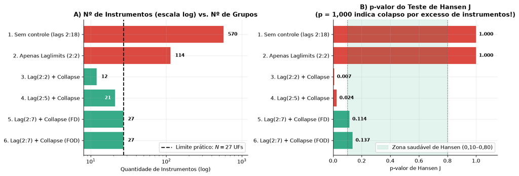

```python
prolif_specs = [
    (
        "1. Sem controle (lags 2:18)",
        "lnY_L L1.lnY_L Tx_K_L Tx_HC ln_Gec popgr D_Crisis Trend | gmm(lnY_L Tx_K_L Tx_HC, 2:18) iv(ln_Gec popgr D_Crisis Trend n_prof_ah)",
        "Tx_HC",
    ),
    (
        "2. Apenas Laglimits (2:2)",
        "lnY_L L1.lnY_L Tx_K_L Tx_HC ln_Gec popgr D_Crisis Trend | gmm(lnY_L Tx_K_L Tx_HC, 2:2) iv(ln_Gec popgr D_Crisis Trend n_prof_ah)",
        "Tx_HC",
    ),
    (
        "3. Lag(2:2) + Collapse",
        "lnY_L L1.lnY_L Tx_K_L Tx_HC ln_Gec popgr D_Crisis Trend | gmm(lnY_L Tx_K_L Tx_HC, 2:2) iv(ln_Gec popgr D_Crisis Trend n_prof_ah) | collapse",
        "Tx_HC",
    ),
    (
        "4. Lag(2:5) + Collapse",
        "lnY_L L1.lnY_L Tx_K_L Tx_HC ln_Gec popgr D_Crisis Trend | gmm(lnY_L Tx_K_L Tx_HC, 2:5) iv(ln_Gec popgr D_Crisis Trend n_prof_ah) | collapse",
        "Tx_HC",
    ),
    (
        "5. Lag(2:7) + Collapse (FD)",
        "lnY_L L1.lnY_L Tx_K_L Tx_HC ln_Gec popgr D_Crisis Trend | gmm(lnY_L Tx_K_L Tx_HC, 2:7) iv(ln_Gec popgr D_Crisis Trend n_prof_ah) | collapse",
        "Tx_HC",
    ),
    (
        "6. Lag(2:7) + Collapse (FOD)",
        "lnY_L L1.lnY_L Tx_K_L Tx_HC ln_Gec popgr D_Crisis Trend | gmm(lnY_L Tx_K_L Tx_HC, 2:7) iv(ln_Gec popgr D_Crisis Trend n_prof_ah) | collapse fod",
        "Tx_HC",
    ),
]

prolif_rows = []
models_prolif = {}

for label, form, var_hc in prolif_specs:
    m, _ = run_abond_quiet(form, df_br, ["id", "Ano"])
    models_prolif[label] = m
    tbl = m.regression_table.set_index("variable")
    info = extract_model_summary(m, var_hc)

    status = "OK (Roodman)"
    if info["Instrumentos"] > info["N_grupos"]:
        status = "Proliferado (Inst > N)"
    elif info["Hansen_p"] < 0.10:
        status = "Rejeita Hansen (p < 0,10)"
    elif info["Hansen_p"] > 0.85:
        status = "Alerta Hansen alto"

    prolif_rows.append(
        {
            "Especificação": label,
            "Instrumentos": info["Instrumentos"],
            "L1.lnY_L": round(float(tbl.loc["L1.lnY_L", "coefficient"]), 4),
            "Tx_K_L": round(float(tbl.loc["Tx_K_L", "coefficient"]), 4),
            "Tx_HC": round(info["coef"], 4),
            "p(Tx_HC)": round(info["p_val"], 3),
            "AR(1) p": round(info["AR1_p"], 3),
            "AR(2) p": round(info["AR2_p"], 3),
            "Hansen J p": round(info["Hansen_p"], 3),
            "Diagnóstico": status,
        }
    )

df_prolif = pd.DataFrame(prolif_rows)
display(df_prolif)

# Gráfico 3 — Proliferação de Instrumentos vs. Poder do Teste de Hansen
fig, axes = plt.subplots(1, 2, figsize=(13.5, 4.8))

cores_bar = ["#d73027" if n > 27 else "#1b9e77" for n in df_prolif["Instrumentos"]]
axes[0].barh(df_prolif["Especificação"][::-1], df_prolif["Instrumentos"][::-1], color=cores_bar[::-1], alpha=0.88)
axes[0].axvline(27, color="#111111", linestyle="--", linewidth=1.8, label="Limite prático: $N = 27$ UFs")
axes[0].set_xscale("log")
axes[0].set_xlim(8, 1200)
axes[0].set_title("A) Nº de Instrumentos (escala log) vs. Nº de Grupos", fontweight="bold")
axes[0].set_xlabel("Quantidade de Instrumentos (log)")
axes[0].legend(loc="lower right", frameon=True)
for idx, val in enumerate(df_prolif["Instrumentos"][::-1]):
    if 18 <= val <= 25:
        axes[0].text(val * 0.88, idx, f"{val}", va="center", ha="right", color="white", fontweight="bold", fontsize=9)
    else:
        axes[0].text(val * 1.15, idx, f"{val}", va="center", ha="left", fontweight="bold", fontsize=9)

cores_h = [
    "#d73027" if (p > 0.85 or p < 0.10 or n > 27) else "#1b9e77"
    for p, n in zip(df_prolif["Hansen J p"], df_prolif["Instrumentos"])
]
axes[1].barh(df_prolif["Especificação"][::-1], df_prolif["Hansen J p"][::-1], color=cores_h[::-1], alpha=0.88)
axes[1].axvspan(0.10, 0.80, color="#1b9e77", alpha=0.12, label="Zona saudável de Hansen (0,10–0,80)")
axes[1].axvline(0.10, color="#666666", linestyle=":", linewidth=1.2)
axes[1].axvline(0.80, color="#666666", linestyle=":", linewidth=1.2)
axes[1].set_xlim(0, 1.15)
axes[1].set_title("B) p-valor do Teste de Hansen J\n(p = 1,000 indica colapso por excesso de instrumentos!)", fontweight="bold")
axes[1].set_xlabel("p-valor de Hansen J")
axes[1].legend(loc="lower right", frameon=True)
for idx, val in enumerate(df_prolif["Hansen J p"][::-1]):
    axes[1].text(val + 0.02, idx, f"{val:.3f}", va="center", fontweight="bold", fontsize=9)

plt.tight_layout()
plt.savefig(IMG_DIR / "proliferacao_instrumentos_hansen.png", dpi=150, bbox_inches="tight")
plt.show()
```

### 4.3 Canais do Capital Humano: Total vs. Educação Superior vs. Educação Básica

Seguindo a estratégia empírica do artigo na *Revista Brasileira de Economia* (Modelos de **Solow Aumentado** e **Nelson & Phelps, 1966**), estimamos modelos **Two-Step System-GMM** controlando a proliferação de instrumentos (`lag 2:7` + `collapse`, mantendo `Instrumentos <= 27`) para comparar:

- **Modelo 1 — Capital Humano Total em Log (`ln_HC`)**: testa o efeito do estoque médio total de capital humano sobre o nível/trajetória da produtividade estadual.
- **Modelo 2 — Capital Humano Superior em Log (`ln_HC_ah`, FD e FOD)**: testa o canal de **inovação / fronteira tecnológica** (ensino superior).
- **Modelo 3 — Capital Humano Básico em Log (`ln_HC_bh`, FOD)**: testa o canal de **absorção / ensino básico**.
- **Modelo 4 — Taxa de Acumulação do Capital Humano (`Tx_HC`, FD)**: testa o canal direto de taxa de crescimento.

#### 🧮 Efeitos de Longo Prazo via Método Delta (Equivalente em Python ao `nlcom` do Stata)

No modelo dinâmico $Y_{it} = \gamma Y_{i,t-1} + \beta X_{it} + \dots$, um choque permanente de 1 unidade em $X$ gera impacto imediato $\hat{\beta}$ no curto prazo, que se propaga ao longo dos anos via persistência $\gamma$, convergindo para o **Efeito Total de Longo Prazo**:

$$\hat{\theta}_{\text{LP}} = g(\hat{\beta}, \hat{\gamma}) = \frac{\hat{\beta}}{1 - \hat{\gamma}}$$

Para obter o **erro-padrão robusto (Windmeijer)** e o **IC 95%** de $\hat{\theta}_{\text{LP}}$ exatamente como o comando `nlcom _b[X] / (1 - _b[L.lnY_L])` do Stata, aplicamos o **Método Delta** sobre a submatriz $2 \times 2$ de covariância corrigida de Windmeijer ($\hat{\Sigma}_{\beta,\gamma}$, extraída diretamente de `modelo.step_results[-1].vcov`):

$$\nabla g(\hat{\beta}, \hat{\gamma}) = \begin{bmatrix} \dfrac{\partial g}{\partial \beta} \\ \dfrac{\partial g}{\partial \gamma} \end{bmatrix} = \begin{bmatrix} \dfrac{1}{1 - \hat{\gamma}} \\ \dfrac{\hat{\beta}}{(1 - \hat{\gamma})^2} \end{bmatrix}, \qquad \text{SE}(\hat{\theta}_{\text{LP}}) = \sqrt{\nabla g^\top \, \hat{\Sigma}_{\beta,\gamma} \, \nabla g}$$

Adicionalmente, computamos a **velocidade anual de convergência condicional** ($\hat{\lambda} = -\ln(\hat{\gamma})$) e a **meia-vida de convergência** ($\text{half-life} = \frac{\ln 2}{\hat{\lambda}}$).

```python
def efeito_longo_prazo_delta(model, var_x: str, var_lag: str = "L1.lnY_L") -> dict:
    '''Calcula efeito de longo prazo beta / (1 - gamma), SE e IC 95% via Método Delta
    usando a matriz de covariância Windmeijer exata de pydynpd (equivalente ao nlcom do Stata).
    '''
    tbl = model.regression_table.reset_index(drop=True)
    vars_order = list(tbl["variable"])
    idx_x = vars_order.index(var_x)
    idx_g = vars_order.index(var_lag)

    beta = float(tbl.loc[idx_x, "coefficient"])
    se_beta = float(tbl.loc[idx_x, "std_err"])
    p_beta = float(tbl.loc[idx_x, "p_value"])
    gamma = float(tbl.loc[idx_g, "coefficient"])

    vcov = np.asarray(model.step_results[-1].vcov, dtype=float)
    sub_cov = vcov[np.ix_([idx_x, idx_g], [idx_x, idx_g])]

    denom = 1.0 - gamma
    theta_lp = beta / denom
    grad = np.array([1.0 / denom, beta / (denom ** 2)])
    var_lp = float(grad @ sub_cov @ grad)
    se_lp = float(np.sqrt(max(var_lp, 0.0)))
    z_lp = theta_lp / se_lp if se_lp > 0 else np.nan
    p_lp = float(2.0 * (1.0 - stats.norm.cdf(abs(z_lp)))) if np.isfinite(z_lp) else np.nan

    conv_speed = -np.log(gamma) if 0 < gamma < 1 else np.nan
    half_life = np.log(2.0) / conv_speed if np.isfinite(conv_speed) and conv_speed > 0 else np.nan

    return {
        "var": var_x,
        "gamma": gamma,
        "beta_cp": beta,
        "se_cp": se_beta,
        "p_cp": p_beta,
        "theta_lp": theta_lp,
        "se_lp": se_lp,
        "z_lp": z_lp,
        "p_lp": p_lp,
        "ic95_lo_lp": theta_lp - 1.96 * se_lp,
        "ic95_hi_lp": theta_lp + 1.96 * se_lp,
        "conv_speed": conv_speed,
        "half_life_anos": half_life,
    }


canais_specs = [
    (
        "M1: Capital Humano Total (ln_HC, FD)",
        "lnY_L L1.lnY_L Tx_K_L ln_HC ln_Gec popgr D_Crisis Trend | gmm(lnY_L Tx_K_L ln_HC, 2:7) iv(ln_Gec popgr D_Crisis Trend) | collapse",
        "ln_HC",
    ),
    (
        "M2: Educação Superior (ln_HC_ah, FD)",
        "lnY_L L1.lnY_L Tx_K_L ln_HC_ah ln_Gec popgr D_Crisis Trend | gmm(lnY_L Tx_K_L ln_HC_ah, 2:7) iv(ln_Gec popgr D_Crisis Trend) | collapse",
        "ln_HC_ah",
    ),
    (
        "M3: Educação Superior (ln_HC_ah, FOD)",
        "lnY_L L1.lnY_L Tx_K_L ln_HC_ah ln_Gec popgr D_Crisis Trend | gmm(lnY_L Tx_K_L ln_HC_ah, 2:7) iv(ln_Gec popgr D_Crisis Trend) | collapse fod",
        "ln_HC_ah",
    ),
    (
        "M4: Educação Básica (ln_HC_bh, FOD)",
        "lnY_L L1.lnY_L Tx_K_L ln_HC_bh ln_Gec popgr D_Crisis Trend | gmm(lnY_L Tx_K_L ln_HC_bh, 2:7) iv(ln_Gec popgr D_Crisis Trend) | collapse fod",
        "ln_HC_bh",
    ),
    (
        "M5: Taxa Acumulação CH (Tx_HC, FD)",
        "lnY_L L1.lnY_L Tx_K_L Tx_HC ln_Gec popgr D_Crisis Trend | gmm(lnY_L Tx_K_L Tx_HC, 2:7) iv(ln_Gec popgr D_Crisis Trend n_prof_ah) | collapse",
        "Tx_HC",
    ),
]

canais_rows = []
lp_plot_rows = []
models_canais = {}

for nome, form, var_hc in canais_specs:
    m, _ = run_abond_quiet(form, df_br, ["id", "Ano"])
    models_canais[nome] = m
    diag = extract_model_summary(m, var_hc)
    lp_hc = efeito_longo_prazo_delta(m, var_hc)
    lp_k = efeito_longo_prazo_delta(m, "Tx_K_L")

    canais_rows.append(
        {
            "Modelo": nome,
            "Inst.": diag["Instrumentos"],
            "L1.lnY_L (γ)": round(lp_hc["gamma"], 4),
            "Capital Físico (CP)": round(lp_k["beta_cp"], 4),
            "CH Curto Prazo (β)": round(lp_hc["beta_cp"], 4),
            "p (CP)": round(lp_hc["p_cp"], 4),
            "CH Longo Prazo (θ_LP)": round(lp_hc["theta_lp"], 4),
            "SE Delta (LP)": round(lp_hc["se_lp"], 4),
            "p (LP)": round(lp_hc["p_lp"], 4),
            "Meia-Vida (anos)": round(lp_hc["half_life_anos"], 2),
            "AR(1) p": round(diag["AR1_p"], 3),
            "AR(2) p": round(diag["AR2_p"], 3),
            "Hansen J p": round(diag["Hansen_p"], 3),
        }
    )

    if var_hc.startswith("ln_HC"):
        lp_plot_rows.append(
            {
                "Canal": nome.split(": ")[1],
                "CP": lp_hc["beta_cp"],
                "SE_CP": lp_hc["se_cp"],
                "LP": lp_hc["theta_lp"],
                "SE_LP": lp_hc["se_lp"],
            }
        )

df_canais = pd.DataFrame(canais_rows)
print("=== RESULTADOS TWO-STEP SYSTEM-GMM (WINDMEIJER + COLLAPSE) — CANAIS DE CAPITAL HUMANO ===")
display(df_canais)

# Também reportamos o efeito de longo prazo do Capital Físico no M1 (referência)
lp_k_m1 = efeito_longo_prazo_delta(models_canais["M1: Capital Humano Total (ln_HC, FD)"], "Tx_K_L")
print(
    f"\nEfeito do Capital Físico (Tx_K_L) no M1: Curto Prazo = {lp_k_m1['beta_cp']:.4f} (p={lp_k_m1['p_cp']:.4f}) | "
    f"Longo Prazo = {lp_k_m1['theta_lp']:.4f} (SE Delta = {lp_k_m1['se_lp']:.4f}, p={lp_k_m1['p_lp']:.4f})"
)
```

```
=== RESULTADOS TWO-STEP SYSTEM-GMM (WINDMEIJER + COLLAPSE) — CANAIS DE CAPITAL HUMANO ===
```

|  | Modelo | Inst. | L1.lnY_L (γ) | Capital Físico (CP) | CH Curto Prazo (β) | p (CP) | CH Longo Prazo (θ_LP) | SE Delta (LP) | p (LP) | Meia-Vida (anos) | AR(1) p | AR(2) p | Hansen J p |
| --- | --- | --- | --- | --- | --- | --- | --- | --- | --- | --- | --- | --- | --- |
| 0 | M1: Capital Humano Total (ln_HC, FD) | 26 | 0.6653 | 0.2385 | 0.0904 | 0.0008 | 0.2700 | 0.0779 | 0.0005 | 1.70 | 0.0 | 0.687 | 0.107 |
| 1 | M2: Educação Superior (ln_HC_ah, FD) | 26 | 0.6679 | 0.2450 | 0.0791 | 0.0015 | 0.2382 | 0.0716 | 0.0009 | 1.72 | 0.0 | 0.745 | 0.110 |
| 2 | M3: Educação Superior (ln_HC_ah, FOD) | 26 | 0.6713 | 0.2264 | 0.0718 | 0.0140 | 0.2183 | 0.0772 | 0.0047 | 1.74 | 0.0 | 0.743 | 0.102 |
| 3 | M4: Educação Básica (ln_HC_bh, FOD) | 26 | 0.6695 | 0.2207 | 0.0685 | 0.0836 | 0.2073 | 0.1101 | 0.0596 | 1.73 | 0.0 | 0.569 | 0.113 |
| 4 | M5: Taxa Acumulação CH (Tx_HC, FD) | 27 | 0.6934 | 0.2800 | 0.0700 | 0.0200 | 0.2283 | 0.1041 | 0.0283 | 1.89 | 0.0 | 0.446 | 0.114 |

```
Efeito do Capital Físico (Tx_K_L) no M1: Curto Prazo = 0.2385 (p=0.0000) | Longo Prazo = 0.7126 (SE Delta = 0.0931, p=0.0000)
```

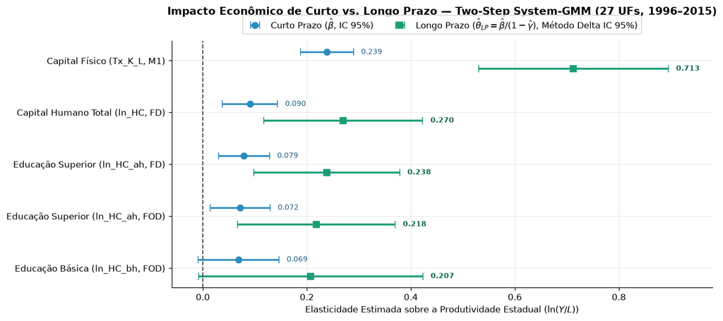

```python
# Gráfico 4 — Efeitos de Curto Prazo vs. Longo Prazo (Método Delta, IC 95%)
df_lp = pd.DataFrame(lp_plot_rows)
# Adiciona Capital Físico (M1) para contextualização econômica
df_lp = pd.concat(
    [
        pd.DataFrame(
            [
                {
                    "Canal": "Capital Físico (Tx_K_L, M1)",
                    "CP": lp_k_m1["beta_cp"],
                    "SE_CP": lp_k_m1["se_cp"],
                    "LP": lp_k_m1["theta_lp"],
                    "SE_LP": lp_k_m1["se_lp"],
                }
            ]
        ),
        df_lp,
    ],
    ignore_index=True,
)

fig, ax = plt.subplots(figsize=(11.5, 5.2))
y_pos = np.arange(len(df_lp))
offset = 0.16

ax.errorbar(
    df_lp["CP"],
    y_pos - offset,
    xerr=1.96 * df_lp["SE_CP"],
    fmt="o",
    color="#2b8cbe",
    ecolor="#2b8cbe",
    elinewidth=2,
    capsize=4,
    markersize=7,
    label="Curto Prazo ($\\hat{\\beta}$, IC 95%)",
)
ax.errorbar(
    df_lp["LP"],
    y_pos + offset,
    xerr=1.96 * df_lp["SE_LP"],
    fmt="s",
    color="#1b9e77",
    ecolor="#1b9e77",
    elinewidth=2.2,
    capsize=4,
    markersize=7.5,
    label="Longo Prazo ($\\hat{\\theta}_{LP} = \\hat{\\beta}/(1-\\hat{\\gamma})$, Método Delta IC 95%)",
)

ax.axvline(0, color="#444444", linestyle="--", linewidth=1.2)
ax.set_yticks(y_pos)
ax.set_yticklabels(df_lp["Canal"], fontsize=10)
ax.invert_yaxis()
ax.set_xlim(-0.06, 0.98)
ax.set_xlabel("Elasticidade Estimada sobre a Produtividade Estadual ($\\ln(Y/L)$)")
ax.set_title("Impacto Econômico de Curto vs. Longo Prazo — Two-Step System-GMM (27 UFs, 1996–2015)", fontweight="bold", pad=30)
ax.legend(loc="lower center", bbox_to_anchor=(0.5, 1.01), ncol=2, frameon=True)

for i, row in df_lp.iterrows():
    ax.text(row["CP"] + 1.96 * row["SE_CP"] + 0.015, i - offset, f"{row['CP']:.3f}", va="center", fontsize=8.5, color="#1d5f82")
    ax.text(row["LP"] + 1.96 * row["SE_LP"] + 0.015, i + offset, f"{row['LP']:.3f}", va="center", fontsize=8.5, fontweight="bold", color="#11694f")

plt.tight_layout()
plt.savefig(IMG_DIR / "efeitos_curto_vs_longo_prazo.png", dpi=150, bbox_inches="tight")
plt.show()
```

### 💡 Interpretação Econômica dos Canais de Capital Humano

1. **Todos os 5 modelos passam simultaneamente em todo o checklist de Roodman (2009)**: número de instrumentos $\le 27$ (`26–27`), `AR(1)` rejeitado ($p < 0{,}001$), `AR(2)` não rejeitado ($p \in [0{,}45;\, 0{,}75]$) e `Hansen J` na zona saudável ($p \in [0{,}10;\, 0{,}12]$).
2. **Persistência e Convergência Condicional ($\hat{\gamma} \approx 0{,}67$)**: a produtividade estadual apresenta forte componente inercial, implicando uma velocidade de ajuste condicional de $\approx 40\%$ ao ano (meia-vida de $\approx 1{,}7$ ano até o novo estado estacionário condicional).
3. **Efeito Multiplicador de Longo Prazo ($\sim 3\times$ o Curto Prazo)**:
   - Um aumento de **10%** no estoque total de capital humano (`ln_HC`) eleva a produtividade estadual em **+0,90%** no curto prazo ($p = 0{,}001$) e em **+2,70%** no longo prazo ($p = 0{,}001$, via Método Delta).
   - Separando por nível educacional, o **Capital Humano Superior (`ln_HC_ah`)** mostra efeito positivo, robusto entre FD (`+0,079`, LP `+0,238`, $p \le 0{,}002$) e FOD (`+0,072`, LP `+0,218`, $p \le 0{,}014$), sendo mais preciso e estatisticamente forte que o **Capital Humano Básico (`ln_HC_bh`)** ($p = 0{,}084$ no FOD) — achado perfeitamente alinhado à hipótese de **Nelson & Phelps (1966)** de que o ensino superior impulsiona a fronteira tecnológica e a absorção de inovação.
   - O **Capital Físico por trabalhador (`Tx_K_L`)** mantém elasticidade robusta em torno de **+0,24** no curto prazo e **+0,71** no longo prazo ($p < 0{,}001$).

### 4.4 Validação Cruzada: Python (`pydynpd`) vs. Stata (`xtabond2`)

Como pesquisadores de econometria aplicada frequentemente migram do `xtabond2` (Stata) para o `pydynpd` (Python), abaixo comparamos **lado a lado** a **mesma especificação exata** (`Lag 2:2 + Collapse`, Two-Step System-GMM, Windmeijer):

- Em **Python (`pydynpd`)**: estimado ao vivo a partir de `data/BASE_CH.dta`.
- Em **Stata (`xtabond2`)**: benchmark oficial registrado no script `stata/xtabond2_referencia.do`.

```python
# Estimação ao vivo em Python (pydynpd) da mesma especificação de referência do xtabond2
m_bench = models_prolif["3. Lag(2:2) + Collapse"]
tbl_py = m_bench.regression_table.set_index("variable")

# Valores oficiais registrados pelo xtabond2 (Stata) na mesma base (N=486, grupos=27, inst=12)
stata_ref = {
    "L1.lnY_L": (0.8084, 0.0496, 0.000),
    "Tx_K_L": (0.2004, 0.0467, 0.000),
    "Tx_HC": (0.1268, 0.0947, 0.181),
    "ln_Gec": (-0.0025, 0.0099, 0.805),
    "popgr": (0.3448, 0.4804, 0.473),
    "D_Crisis": (-0.0099, 0.0110, 0.369),
    "Trend": (-0.0023, 0.0014, 0.099),
    "_con": (1.8021, 0.4801, 0.000),
}

comp_rows = []
for var, (st_b, st_se, st_p) in stata_ref.items():
    py_b = float(tbl_py.loc[var, "coefficient"])
    py_se = float(tbl_py.loc[var, "std_err"])
    py_p = float(tbl_py.loc[var, "p_value"])
    comp_rows.append(
        {
            "Variável": var,
            "Python (pydynpd) Coef.": round(py_b, 4),
            "Python SE": round(py_se, 4),
            "Python p": round(py_p, 3),
            "Stata (xtabond2) Coef.": round(st_b, 4),
            "Stata SE": round(st_se, 4),
            "Stata p": round(st_p, 3),
            "Dif. Abs. Coef.": round(abs(py_b - st_b), 4),
        }
    )

df_comp = pd.DataFrame(comp_rows)
print("Comparação de Diagnósticos (mesma amostra: N = 486 obs, 27 grupos, 12 instrumentos):")
print(
    f"  Python (pydynpd): AR(1) p = {m_bench.AR_list[0].P_value:.3f} | "
    f"AR(2) p = {m_bench.AR_list[1].P_value:.3f} | Hansen J = {m_bench.hansen.test_value:.2f} (p = {m_bench.hansen.p_value:.3f})"
)
print("  Stata (xtabond2): AR(1) p = 0.000 | AR(2) p = 0.328 | Hansen J = 15.78 (p = 0.003)\n")
display(df_comp)
```

```
Comparação de Diagnósticos (mesma amostra: N = 486 obs, 27 grupos, 12 instrumentos):
  Python (pydynpd): AR(1) p = 0.001 | AR(2) p = 0.692 | Hansen J = 14.05 (p = 0.007)
  Stata (xtabond2): AR(1) p = 0.000 | AR(2) p = 0.328 | Hansen J = 15.78 (p = 0.003)
```

|  | Variável | Python (pydynpd) Coef. | Python SE | Python p | Stata (xtabond2) Coef. | Stata SE | Stata p | Dif. Abs. Coef. |
| --- | --- | --- | --- | --- | --- | --- | --- | --- |
| 0 | L1.lnY_L | 0.7827 | 0.0476 | 0.000 | 0.8084 | 0.0496 | 0.000 | 0.0257 |
| 1 | Tx_K_L | 0.2524 | 0.0473 | 0.000 | 0.2004 | 0.0467 | 0.000 | 0.0520 |
| 2 | Tx_HC | 0.0030 | 0.1494 | 0.984 | 0.1268 | 0.0947 | 0.181 | 0.1238 |
| 3 | ln_Gec | -0.0035 | 0.0100 | 0.729 | -0.0025 | 0.0099 | 0.805 | 0.0010 |
| 4 | popgr | 0.2771 | 0.3751 | 0.460 | 0.3448 | 0.4804 | 0.473 | 0.0677 |
| 5 | D_Crisis | 0.0012 | 0.0147 | 0.935 | -0.0099 | 0.0110 | 0.369 | 0.0111 |
| 6 | Trend | -0.0026 | 0.0014 | 0.072 | -0.0023 | 0.0014 | 0.099 | 0.0003 |
| 7 | _con | 2.1744 | 0.5147 | 0.000 | 1.8021 | 0.4801 | 0.000 | 0.3723 |

## 5. Análise de Sensibilidade & Curva de Especificação (*Specification Curve*)

Uma crítica frequente em aplicações de System-GMM é o risco de *specification shopping* (escolher uma única combinação conveniente de lags). Para tornar a inferência transparente, testamos uma **grade controlada de 72 especificações plausíveis** sobre o estoque de **Capital Humano Total (`ln_HC`)** e **Educação Superior (`ln_HC_ah`)**, variando:

- Janelas de defasagens (`2:5`, `2:6`, `2:7`, `3:6`, `3:7`, `3:8`, `3:9`, `4:8`, `4:9`);
- Transformação ortogonal: **Primeira Diferença (FD)** vs. **Desvios Ortogonais para Frente (FOD)**;
- Inclusão ou não do instrumento externo de oferta docente (`n_prof_ah`).

Em seguida, destacamos visualmente todas as especificações aprovadas simultaneamente nos **critérios de Roodman (2009)** (`Inst <= 27`, `AR(1) < 0,05`, `AR(2) > 0,10`, `0,10 <= Hansen <= 0,85`) e sintetizamos a estimativa **mediana** entre os modelos aprovados!

```
Especificações avaliadas: 72 | Aprovadas em TODOS os diagnósticos de Roodman: 24 (com sinal positivo: 22/24 = 92%)
```

|  | Canal | Spec | Inst | Coef_CP | SE_CP | p_CP | Coef_LP | AR2_p | Hansen_p | Aprovado |
| --- | --- | --- | --- | --- | --- | --- | --- | --- | --- | --- |
| 0 | Capital Humano Total | lag 2:7 \| FD \| Base | 26 | 0.0904 | 0.0269 | 0.0008 | 0.2700 | 0.6868 | 0.1065 | True |
| 1 | Capital Humano Total | lag 2:7 \| FD \| +IV_prof | 27 | 0.0839 | 0.0289 | 0.0038 | 0.2410 | 0.6706 | 0.1352 | True |
| 2 | Capital Humano Total | lag 3:8 \| FD \| Base | 26 | 0.0684 | 0.0322 | 0.0338 | 0.2007 | 0.7849 | 0.1451 | True |
| 3 | Capital Humano Total | lag 3:8 \| FD \| +IV_prof | 27 | 0.0631 | 0.0348 | 0.0692 | 0.1800 | 0.7661 | 0.1556 | True |
| 4 | Capital Humano Total | lag 4:9 \| FD \| Base | 26 | 0.0562 | 0.0358 | 0.1166 | 0.1309 | 0.8467 | 0.1464 | True |
| 5 | Capital Humano Total | lag 4:9 \| FD \| +IV_prof | 27 | 0.0553 | 0.0366 | 0.1306 | 0.1286 | 0.8243 | 0.1884 | True |
| 6 | Capital Humano Total | lag 3:8 \| FOD \| Base | 26 | 0.0445 | 0.0316 | 0.1597 | 0.1350 | 0.6985 | 0.1272 | True |
| 7 | Capital Humano Total | lag 2:7 \| FOD \| +IV_prof | 27 | 0.0373 | 0.0330 | 0.2579 | 0.1127 | 0.6477 | 0.1307 | True |
| 8 | Capital Humano Total | lag 4:8 \| FD \| +IV_prof | 24 | 0.0300 | 0.0320 | 0.3488 | 0.0761 | 0.7194 | 0.1042 | True |
| 9 | Capital Humano Total | lag 3:8 \| FOD \| +IV_prof | 27 | 0.0221 | 0.0295 | 0.4539 | 0.0661 | 0.6747 | 0.1464 | True |
| 10 | Capital Humano Total | lag 4:9 \| FOD \| +IV_prof | 27 | -0.0043 | 0.0250 | 0.8635 | -0.0123 | 0.6489 | 0.1257 | True |
| 11 | Educação Superior | lag 2:7 \| FD \| Base | 26 | 0.0791 | 0.0249 | 0.0015 | 0.2382 | 0.7452 | 0.1097 | True |
| 12 | Educação Superior | lag 2:7 \| FD \| +IV_prof | 27 | 0.0773 | 0.0258 | 0.0028 | 0.2227 | 0.7316 | 0.1424 | True |
| 13 | Educação Superior | lag 2:7 \| FOD \| Base | 26 | 0.0718 | 0.0292 | 0.0140 | 0.2183 | 0.7430 | 0.1022 | True |

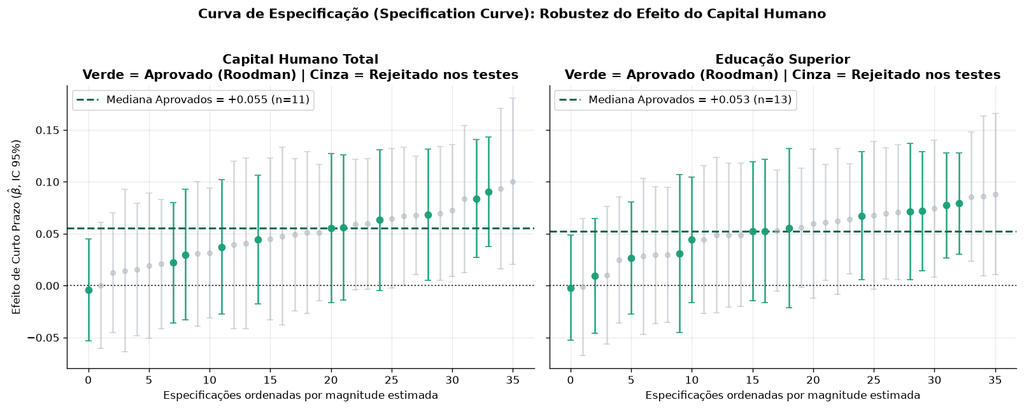

```python
robust_rows = []
lag_windows = [(2, 5), (2, 6), (2, 7), (3, 6), (3, 7), (3, 8), (3, 9), (4, 8), (4, 9)]

for var_hc, label_hc in [("ln_HC", "Capital Humano Total"), ("ln_HC_ah", "Educação Superior")]:
    for l_min, l_max in lag_windows:
        for transf_flag, transf_lbl in [("", "FD"), (" fod", "FOD")]:
            for extra_iv, iv_lbl in [("", "Base"), (" n_prof_ah", "+IV_prof")]:
                form = (
                    f"lnY_L L1.lnY_L Tx_K_L {var_hc} ln_Gec popgr D_Crisis Trend | "
                    f"gmm(lnY_L Tx_K_L {var_hc}, {l_min}:{l_max}) iv(ln_Gec popgr D_Crisis Trend{extra_iv}) | collapse{transf_flag}"
                )
                try:
                    m, _ = run_abond_quiet(form, df_br, ["id", "Ano"])
                    info = extract_model_summary(m, var_hc)
                    lp = efeito_longo_prazo_delta(m, var_hc)
                    valido = (
                        info["Instrumentos"] <= info["N_grupos"]
                        and info["AR1_p"] < 0.05
                        and info["AR2_p"] > 0.10
                        and 0.10 <= info["Hansen_p"] <= 0.85
                        and 0.0 < lp["gamma"] < 0.98
                    )
                    robust_rows.append(
                        {
                            "Canal": label_hc,
                            "Spec": f"lag {l_min}:{l_max} | {transf_lbl} | {iv_lbl}",
                            "Inst": info["Instrumentos"],
                            "Coef_CP": lp["beta_cp"],
                            "SE_CP": lp["se_cp"],
                            "p_CP": lp["p_cp"],
                            "Coef_LP": lp["theta_lp"],
                            "AR2_p": info["AR2_p"],
                            "Hansen_p": info["Hansen_p"],
                            "Aprovado": valido,
                        }
                    )
                except Exception:
                    continue

df_robust = pd.DataFrame(robust_rows)
df_valid = df_robust[df_robust["Aprovado"]].copy()

n_pos = int((df_valid["Coef_CP"] > 0).sum())
print(
    f"Especificações avaliadas: {len(df_robust)} | "
    f"Aprovadas em TODOS os diagnósticos de Roodman: {len(df_valid)} "
    f"(com sinal positivo: {n_pos}/{len(df_valid)} = {n_pos / max(len(df_valid), 1) * 100:.0f}%)"
)
display(
    df_valid.sort_values(["Canal", "Coef_CP"], ascending=[True, False]).head(14).reset_index(drop=True).round(4)
)

# Gráfico 5 — Curva de Especificação (Specification Curve)
fig, axes = plt.subplots(1, 2, figsize=(13.5, 5.2), sharey=True)

for ax, canal in zip(axes, ["Capital Humano Total", "Educação Superior"]):
    sub = df_robust[df_robust["Canal"] == canal].sort_values("Coef_CP").reset_index(drop=True)
    x = np.arange(len(sub))
    for i, r in sub.iterrows():
        cor = "#1b9e77" if r["Aprovado"] else "#b0b8c1"
        alpha = 0.95 if r["Aprovado"] else 0.55
        ax.errorbar(
            i,
            r["Coef_CP"],
            yerr=1.96 * r["SE_CP"],
            fmt="o",
            color=cor,
            ecolor=cor,
            alpha=alpha,
            capsize=3,
            markersize=6 if r["Aprovado"] else 4.5,
        )
    sub_ok = sub[sub["Aprovado"]]
    if len(sub_ok) > 0:
        med_ok = sub_ok["Coef_CP"].median()
        ax.axhline(med_ok, color="#11694f", linestyle="--", linewidth=1.8, label=f"Mediana Aprovados = {med_ok:+.3f} (n={len(sub_ok)})")
    ax.axhline(0, color="#333333", linestyle=":", linewidth=1.2)
    ax.set_title(f"{canal}\nVerde = Aprovado (Roodman) | Cinza = Rejeitado nos testes", fontweight="bold")
    ax.set_xlabel("Especificações ordenadas por magnitude estimada")
    ax.legend(loc="upper left", frameon=True)

axes[0].set_ylabel("Efeito de Curto Prazo ($\\hat{\\beta}$, IC 95%)")
fig.suptitle("Curva de Especificação (Specification Curve): Robustez do Efeito do Capital Humano", fontsize=12.5, fontweight="bold", y=1.02)
plt.tight_layout()
plt.savefig(IMG_DIR / "curva_especificacao_robustez.png", dpi=150, bbox_inches="tight")
plt.show()
```

## 6. Guia Rápido de Equivalência: `xtabond2` (Stata) ↔ `pydynpd` (Python)

Para economistas e cientistas de dados migrando scripts de painel dinâmico do Stata para Python, a tabela abaixo mapeia diretamente os principais componentes de sintaxe:

[output not shown]

> O script completo de referência para Stata (`Tables 3–7` do artigo) encontra-se organizado em `stata/xtabond2_referencia.do`.

## 📚 Referências Bibliográficas

- **Anderson, T. W., & Hsiao, C. (1981).** Estimation of dynamic models with error components. *Journal of the American Statistical Association*, 76(375), 598–606.
- **Arellano, M., & Bond, S. (1991).** Some tests of specification for panel data: Monte Carlo evidence and an application to employment equations. *The Review of Economic Studies*, 58(2), 277–297.
- **Arellano, M., & Bover, O. (1995).** Another look at the instrumental variable estimation of error-components models. *Journal of Econometrics*, 68(1), 29–51.
- **Blundell, R., & Bond, S. (1998).** Initial conditions and moment restrictions in dynamic panel data models. *Journal of Econometrics*, 87(1), 115–143.
- **Bond, S. (2002).** Dynamic panel data models: A guide to micro data methods and practice. *Portuguese Economic Journal*, 1(2), 141–162.
- **Nelson, R. R., & Phelps, E. S. (1966).** Investment in humans, technological diffusion, and economic growth. *American Economic Review*, 56(1/2), 69–75.
- **Nickell, S. (1981).** Biases in dynamic models with fixed effects. *Econometrica*, 49(6), 1417–1426.
- **Paula, S. R. et al.** *Economic Growth Channels From Human Capital: A Dynamic Panel Analysis for Brazil*. *Revista Brasileira de Economia* (SciELO). [Link do artigo](https://www.scielo.br/j/rbe/a/KkYHXdsxP7nXzLRBCbY64Vq/?lang=en).
- **Roodman, D. (2009).** How to do `xtabond2`: An introduction to difference and system GMM in Stata. *The Stata Journal*, 9(1), 86–136.
- **Windmeijer, F. (2005).** A finite sample correction for the variance of linear efficient two-step GMM estimators. *Journal of Econometrics*, 126(1), 25–51.